# HOMEWORK7

KIM DONGWON

2020 6 4

예제1. (handspan.txt) 다음은 167명의 학생들에 대해 성별(Sex)과 신장(Height) 그리고 손 한뼘의 길이(HandSpan)를 측정한 자료이다. (1) 신장과 손 한뼘의 길이는 서로 상관관계가 존재하는가? 표본 상관계수를 구하고 두 변수 의 산점도를 그려보자. 두 변수 사이에 선형적 연관성이 존재하는가? (2) 신장과 손 한뼘의 길이사이에 상관관계가 존재하는지 유의수준 5%에서 검정하여라. (3) 신장(y)과 손 한뼘의 길이(x)에 대해 단순선형회귀모형을 적용해보자. 추정된 회귀식을 구 하고 유의수준 5%에서 회귀 직선의 유의성을 검정하시오. (4) 단순 선형 회귀모형의 적용은 타당한가? 잔차도를 이용하여 답하시오.

```r
handspan<-read.table("C:/Users/r english/Desktop/r/handspan.txt", header = T)
#1
cor(handspan$Height,handspan$HandSpan)
```

```
## [1] 0.7395375
```

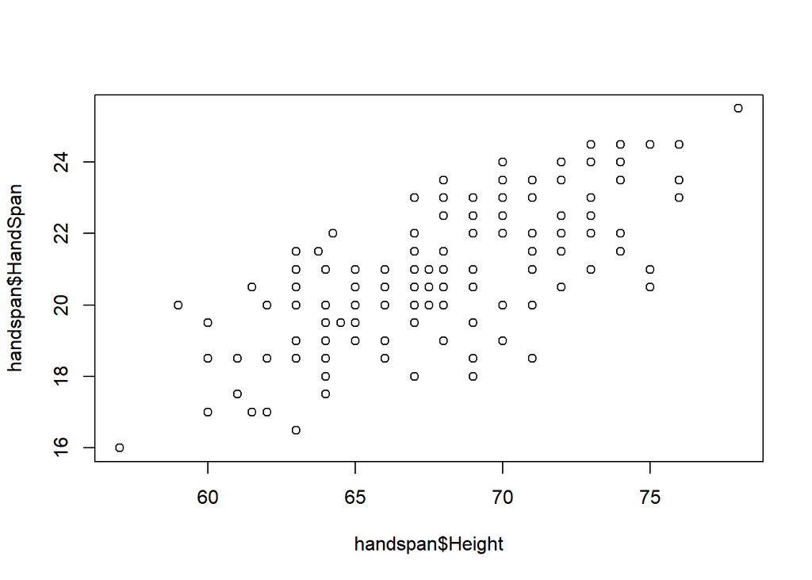

```r
plot(handspan$Height,handspan$HandSpan)
```

```r
#2
cor.test(handspan$Height,handspan$HandSpan)
```

```
##
##  Pearson's product-moment correlation
##
## data:  handspan$Height and handspan$HandSpan
## t = 14.113, df = 165, p-value < 2.2e-16
## alternative hypothesis: true correlation is not equal to 0
## 95 percent confidence interval:
##  0.6620252 0.8013971
## sample estimates:
##       cor
## 0.7395375
```

```r
#3
lm(handspan$Height~handspan$HandSpan)
```

```
##
## Call:
## lm(formula = handspan$Height ~ handspan$HandSpan)
##
## Coefficients:
##       (Intercept)  handspan$HandSpan
##             35.53               1.56
```

```r
handspan.res<- lm(handspan$Height~handspan$HandSpan)
summary(handspan.res)
```

```
##
## Call:
## lm(formula = handspan$Height ~ handspan$HandSpan)
##
## Residuals:
##     Min      1Q  Median      3Q     Max
## -7.7266 -1.7266 -0.1666  1.4933  7.4933
##
## Coefficients:
##                   Estimate Std. Error t value Pr(>|t|)
## (Intercept)        35.5250     2.3160   15.34   <2e-16 ***
## handspan$HandSpan   1.5601     0.1105   14.11   <2e-16 ***
## ---
## Signif. codes:  0 '***' 0.001 '**' 0.01 '*' 0.05 '.' 0.1 ' ' 1
##
## Residual standard error: 2.744 on 165 degrees of freedom
## Multiple R-squared:  0.5469, Adjusted R-squared:  0.5442
## F-statistic: 199.2 on 1 and 165 DF,  p-value: < 2.2e-16
```

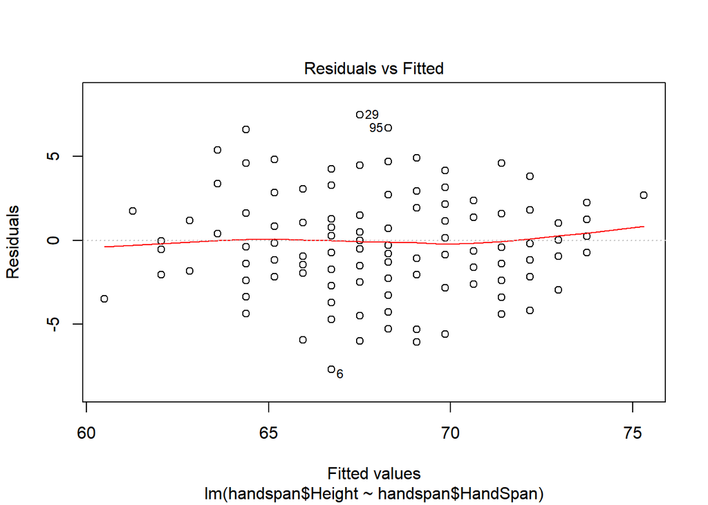

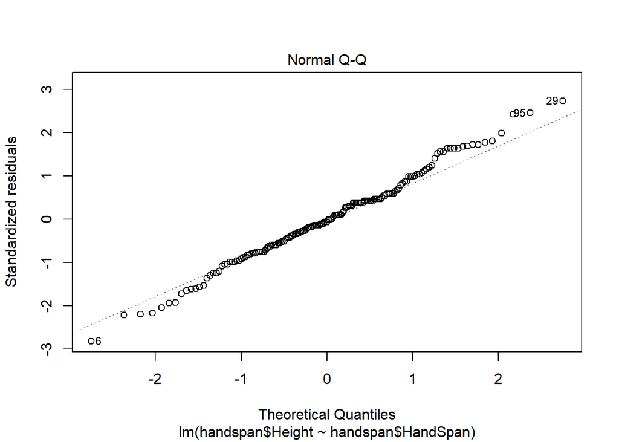

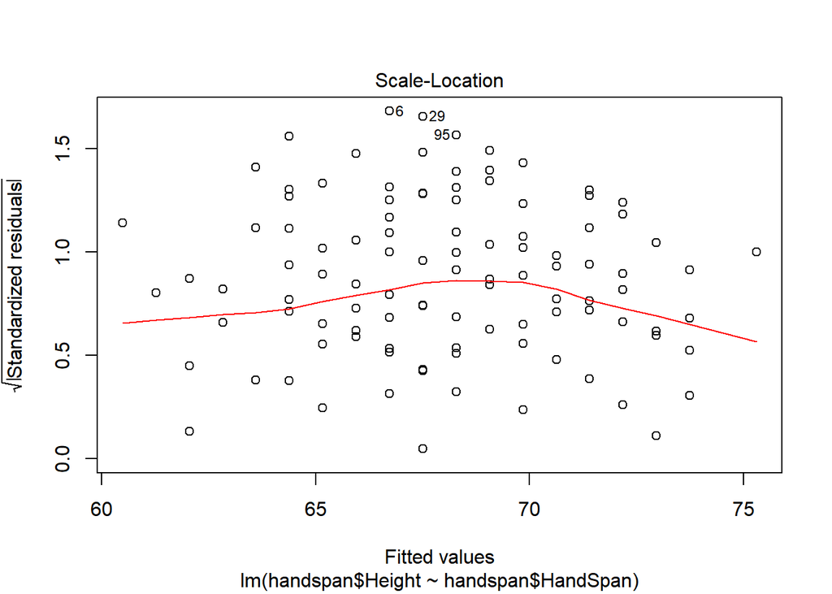

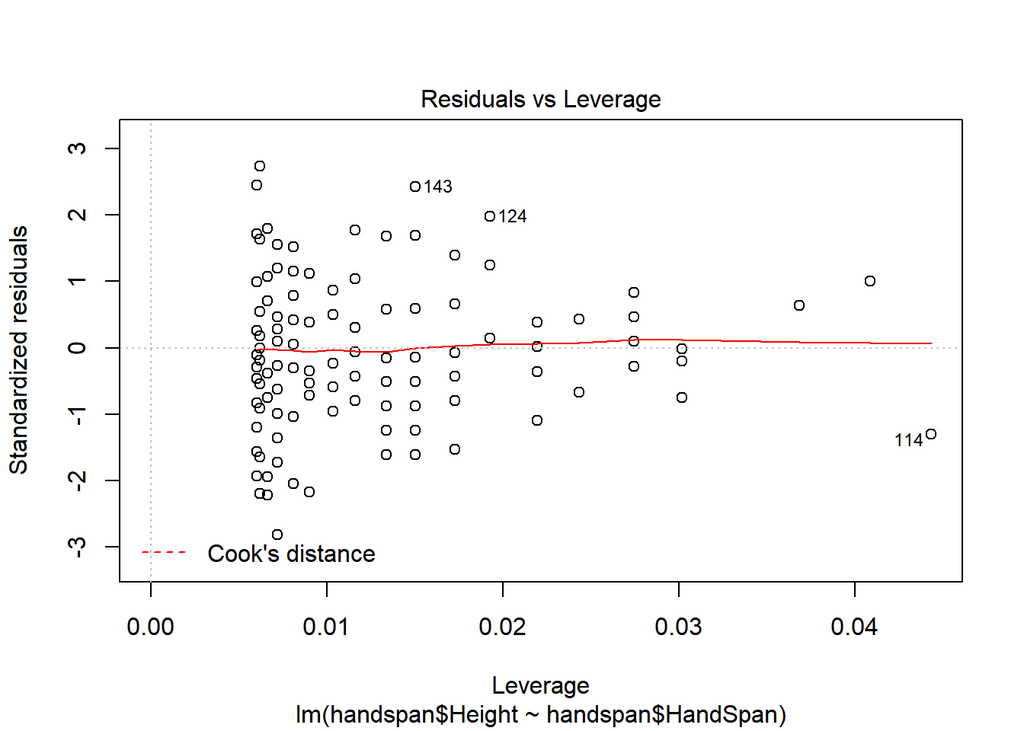

```r
#4
plot(handspan.res)
```

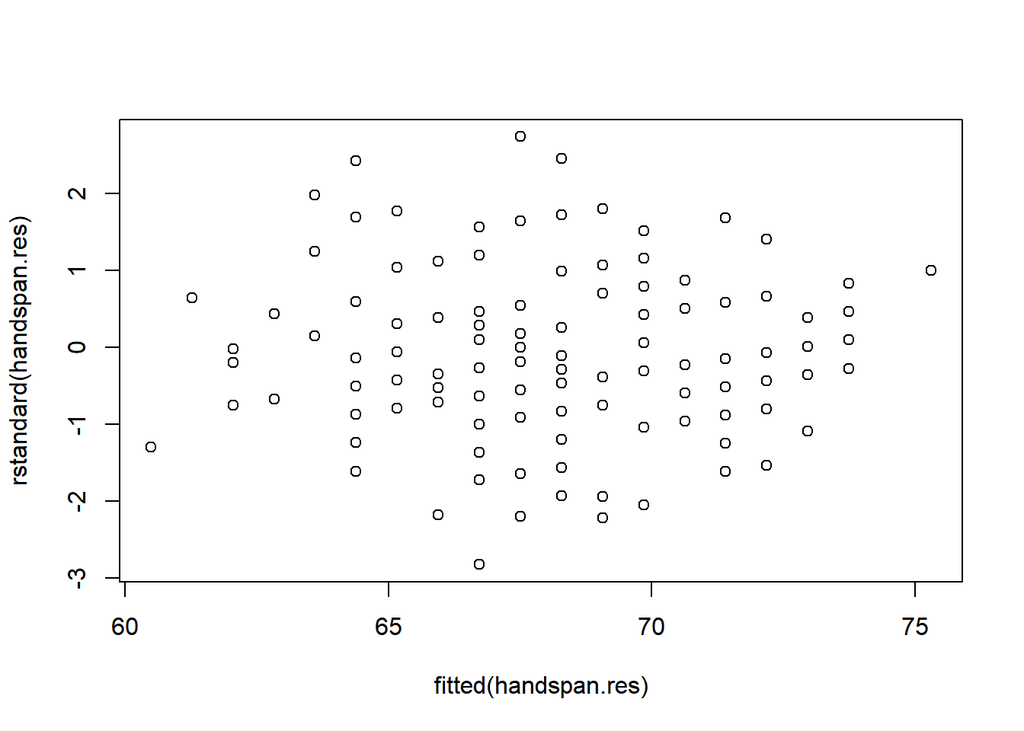

```r
plot(fitted(handspan.res),rstandard(handspan.res))
```

예제2. (carstopping.txt) 주어진 자료는 브레이크가 작동되는 순간의 자동차의 주행 속도 (Speed)에 따른 자동차 제동 거리(StopDist)를 조사한 자료이다. (1) 자동차의 주행 속도에 따른 자동차의 제동거리 간에는 서로 상관관계가 존재하는가? 상관 분석을 통해 이를 확인해보자. (2) 주어진 자료에 단순 선형회귀모형을 적용한 후 결과를 확인해 보자. 유의수준 5%에서 모형은 유의한가? (3) 적합된 회귀 모형의 잔차도를 확인해 보자. 단순선형회귀모형의 적용이 타당하다고 볼 수 있는가? (4) 자동차의 주행속도와 자동차의 제동거리 사이의 산점도를 확인해보자. 두 변수 사이에는 곡률(curvature)관계가 존재하며, 또한 x 값이 증가함에 따라 y값의 산포가 증가하는 것을 확 인할 수 있다. 따라서 주어진 자료에 대해서는 단순 선형회귀 모형의 적용이 적절하지 않다. 이러한 문제를 해결하기 위한 방법 중 하나는 반응변수에 적절한 함수 변환(transformation) 을 취하는 것이다. 즉, 반응변수에 제곱근을 취한 새로운 변수(sqrt.dist)를 만든 후, 새로운 변수 sqrt.dist와 주행속도(Speed)의 산점도를 다시 한번 그려보자. 새로운 산점도는 어떠한 형태를 보이고 있는가? (5) 새로운 변수 sqrt.dist와 Speed에 대해 단순선형회귀모형을 적합 시킨 후 결과를 확인해 보자. 새로운 모형의 결정계수  값은 얼마인가? (1)번에서 구한 모형의 결정계수 값과 비교 해보시오. (6) 새로운 모형의 잔차도를 확인해보자. 단순선형회귀모형의 적용이 타당하다고 볼 수 있는 가?

```r
carstopping<-read.table("C:/Users/r english/Desktop/r/carstopping.txt", header = T)
#1
cor(carstopping$Speed,carstopping$StopDist)
```

```
## [1] 0.9355037
```

```r
cor.test(carstopping$Speed,carstopping$StopDist)
```

```
##
##  Pearson's product-moment correlation
##
## data:  carstopping$Speed and carstopping$StopDist
## t = 20.68, df = 61, p-value < 2.2e-16
## alternative hypothesis: true correlation is not equal to 0
## 95 percent confidence interval:
##  0.8952425 0.9606129
## sample estimates:
##       cor
## 0.9355037
```

```r
#2
lm(carstopping$StopDist~carstopping$Speed)
```

```
##
## Call:
## lm(formula = carstopping$StopDist ~ carstopping$Speed)
##
## Coefficients:
##       (Intercept)  carstopping$Speed
##           -20.273              3.137
```

```r
carstopping.res<-lm(carstopping$StopDist~carstopping$Speed)
summary(carstopping.res)
```

```
##
## Call:
## lm(formula = carstopping$StopDist ~ carstopping$Speed)
##
## Residuals:
##     Min      1Q  Median      3Q     Max
## -25.141  -7.300  -2.141   6.044  35.946
##
## Coefficients:
##                   Estimate Std. Error t value Pr(>|t|)
## (Intercept)       -20.2734     3.2384   -6.26 4.25e-08 ***
## carstopping$Speed   3.1366     0.1517   20.68  < 2e-16 ***
## ---
## Signif. codes:  0 '***' 0.001 '**' 0.01 '*' 0.05 '.' 0.1 ' ' 1
##
## Residual standard error: 11.8 on 61 degrees of freedom
## Multiple R-squared:  0.8752, Adjusted R-squared:  0.8731
## F-statistic: 427.7 on 1 and 61 DF,  p-value: < 2.2e-16
```

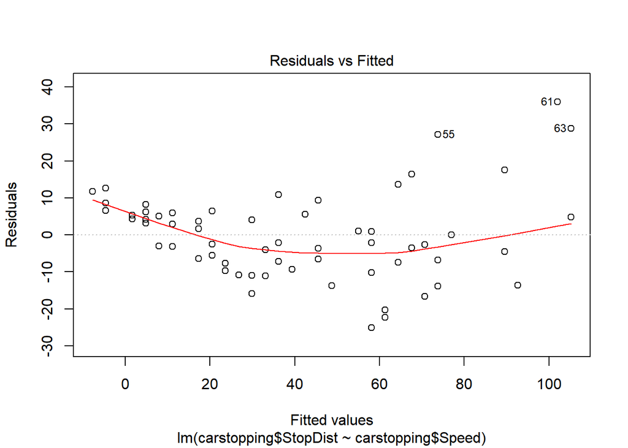

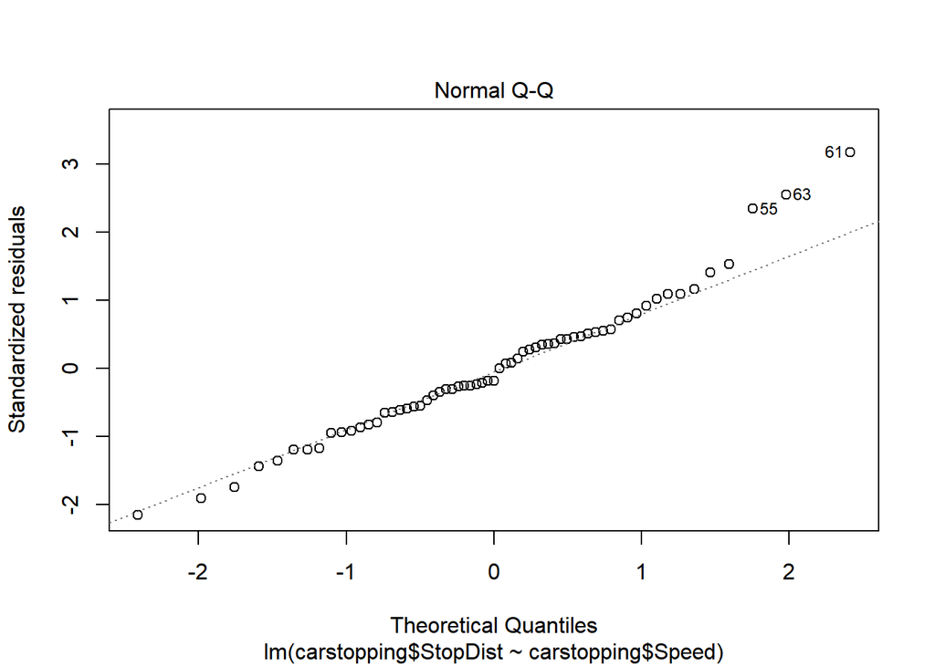

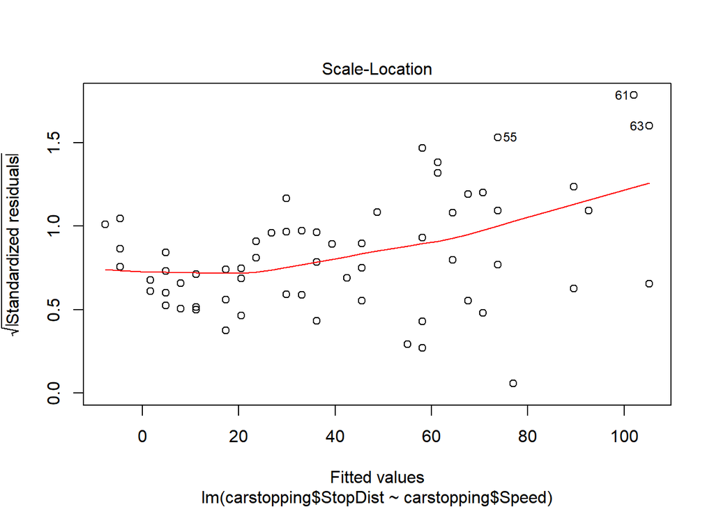

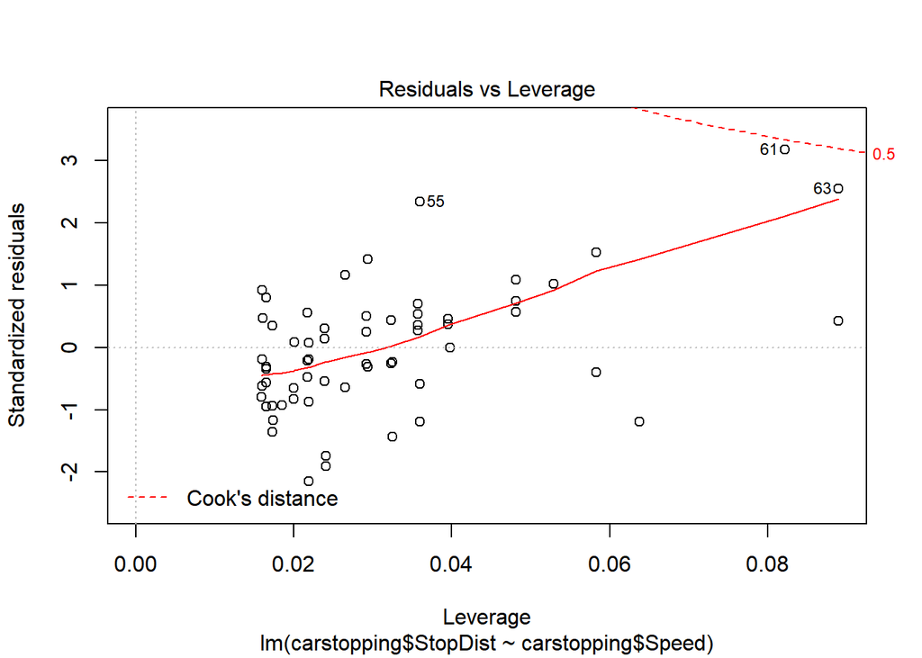

```r
#3
plot(carstopping.res)
```

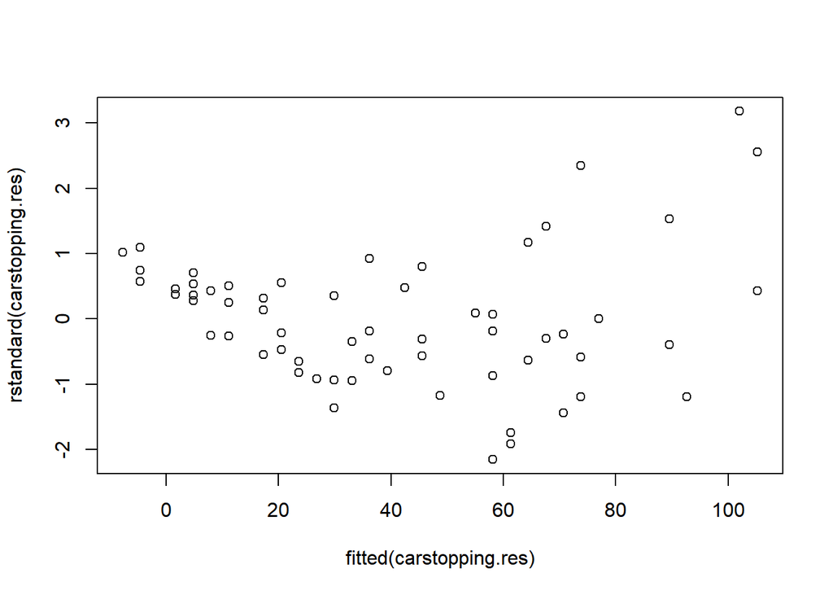

```r
plot(fitted(carstopping.res),rstandard(carstopping.res))
```

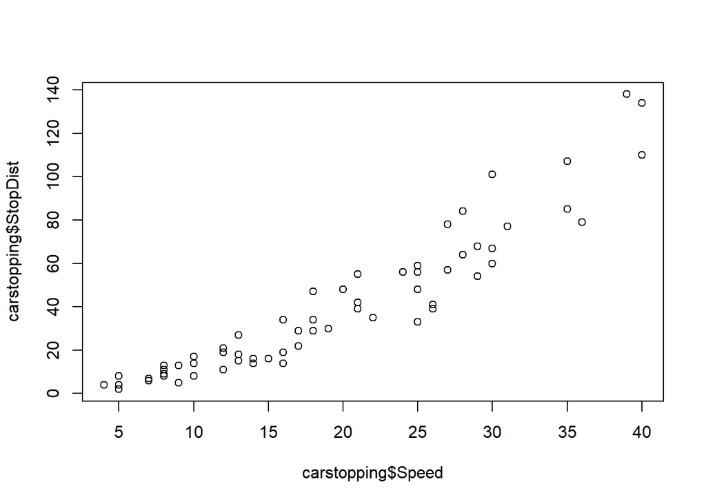

```r
#4
plot(carstopping$Speed,carstopping$StopDist)
```

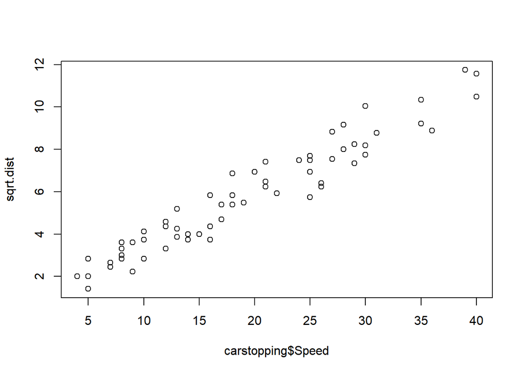

```r
sqrt.dist<-sqrt(carstopping$StopDist)
plot(carstopping$Speed,sqrt.dist)
```

```r
#5
lm(sqrt.dist~carstopping$Speed)
```

```
##
## Call:
## lm(formula = sqrt.dist ~ carstopping$Speed)
##
## Coefficients:
##       (Intercept)  carstopping$Speed
##            0.9183             0.2526
```

```r
carstopping2.res<-lm(sqrt.dist~carstopping$Speed)
summary(carstopping2.res)
```

```
##
## Call:
## lm(formula = sqrt.dist ~ carstopping$Speed)
##
## Residuals:
##     Min      1Q  Median      3Q     Max
## -1.4879 -0.5487  0.0098  0.5291  1.5545
##
## Coefficients:
##                   Estimate Std. Error t value Pr(>|t|)
## (Intercept)       0.918283   0.197406   4.652 1.82e-05 ***
## carstopping$Speed 0.252568   0.009246  27.317  < 2e-16 ***
## ---
## Signif. codes:  0 '***' 0.001 '**' 0.01 '*' 0.05 '.' 0.1 ' ' 1
##
## Residual standard error: 0.7193 on 61 degrees of freedom
## Multiple R-squared:  0.9244, Adjusted R-squared:  0.9232
## F-statistic: 746.2 on 1 and 61 DF,  p-value: < 2.2e-16
```

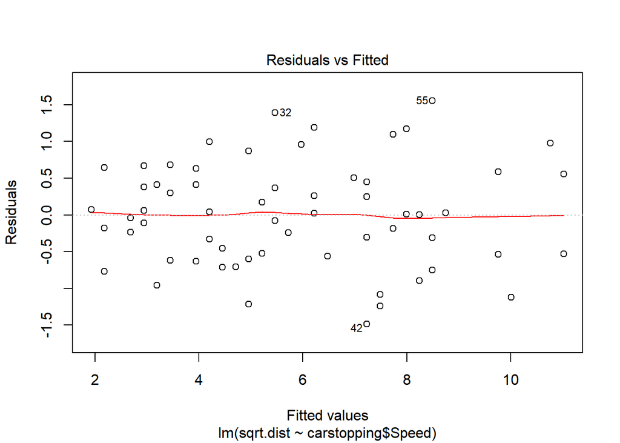

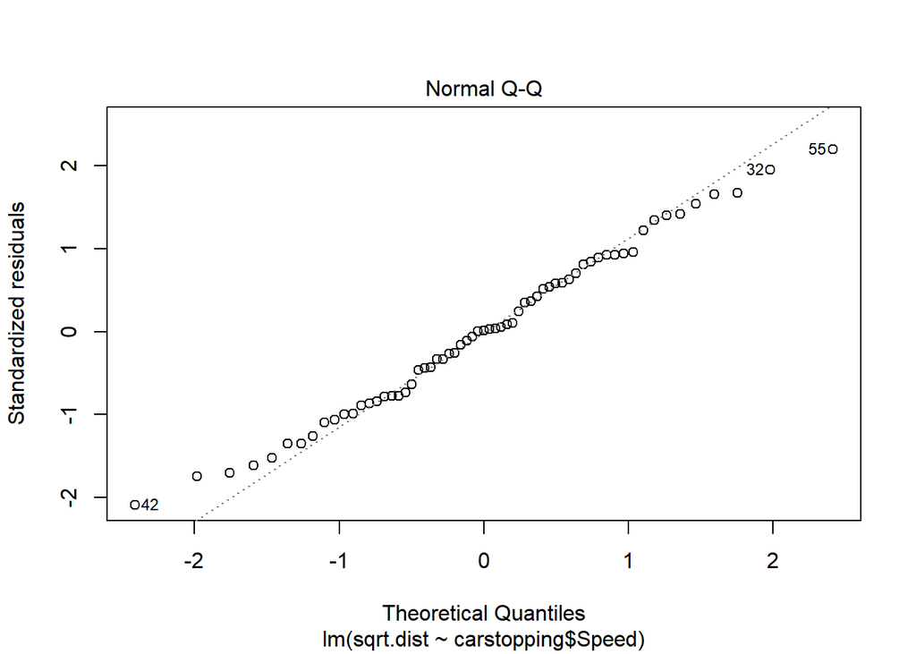

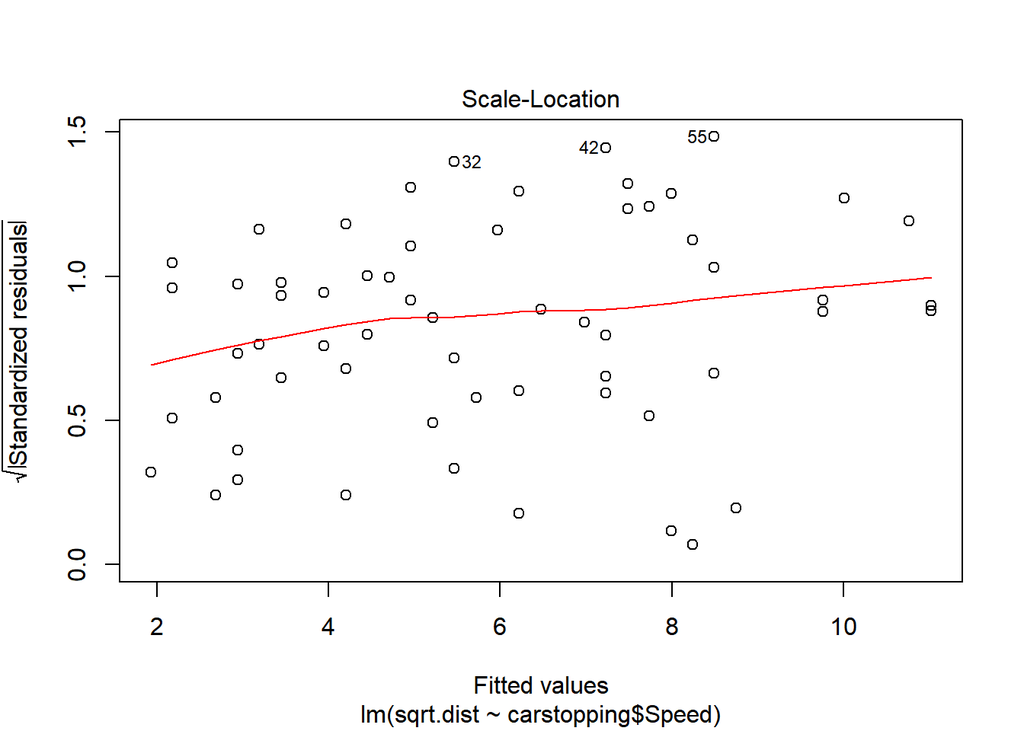

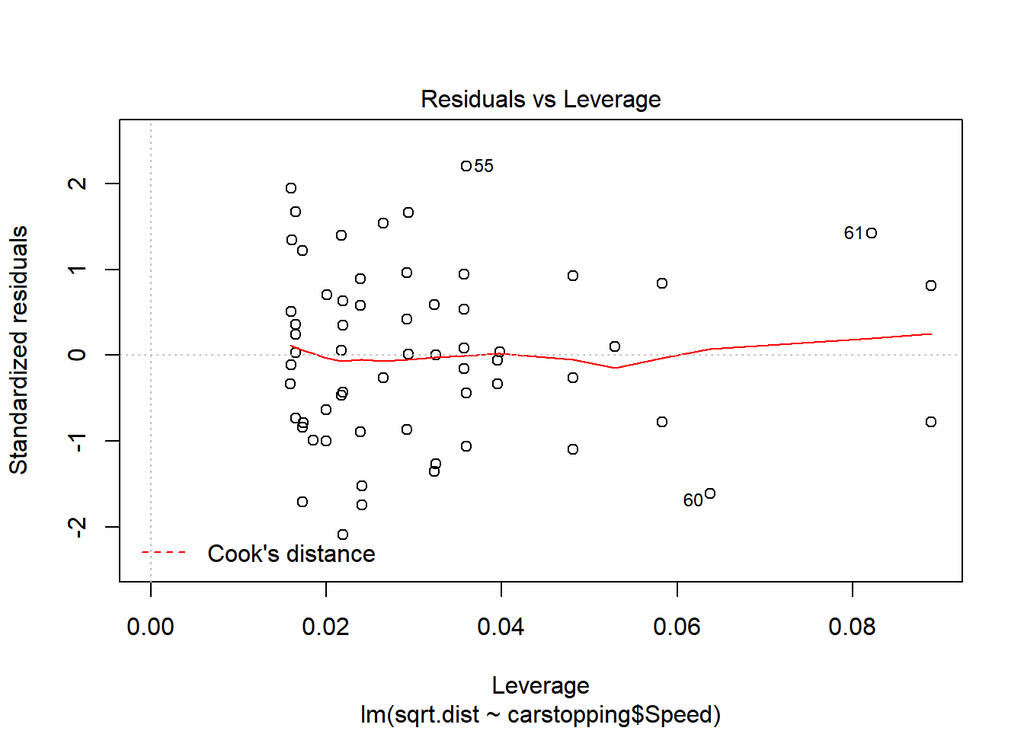

```r
#6
plot(carstopping2.res)
```

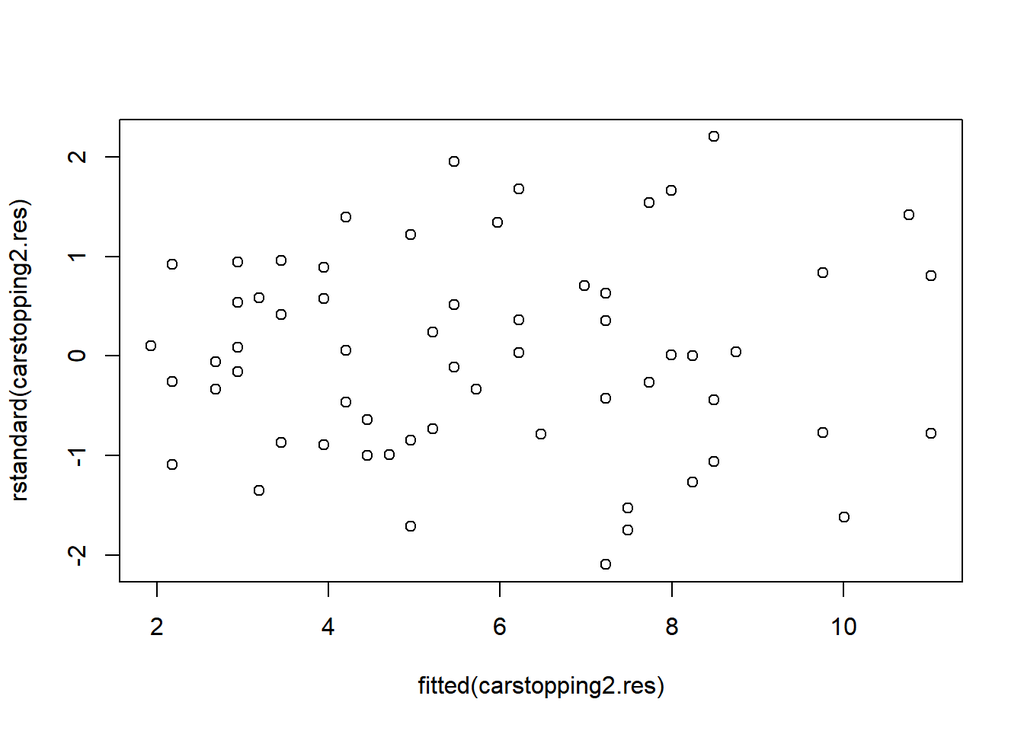

```r
plot(fitted(carstopping2.res),rstandard(carstopping2.res))
```

예제3 (hospital.txt) 다음은 미국 내 113개의 병원들을 대상으로 입원 기간 동안 환자들이 받는 감염 위험과 관련된 사항들을 조사하였다. 다음은 주요 변수에 대한 설명이다. 변수명 설명 InfctRsk 종속변수. 감염 위험 정도 Stay 설명변수1. 환자들의 평균 입원 기간 Age 설명변수2. 환자들의 평균 나이 Xray 설명변수3. 해당 병원의 X-ray 검진 횟수 (1) 종속변수와 각 설명변수들 간에는 유의한 상관관계가 존재하는가? 산점도와 상관분석을 통해 이를 확인해보시오. (2) 주어진 자료에 다중선형회귀모형을 적용해보자. 유의수준 5%에서 모형은 유의하다고 할 수 있는가? 각 변수들은 유의한가? (3) 다중선형회귀모형의 적용은 타당하다고 볼 수 있는가?

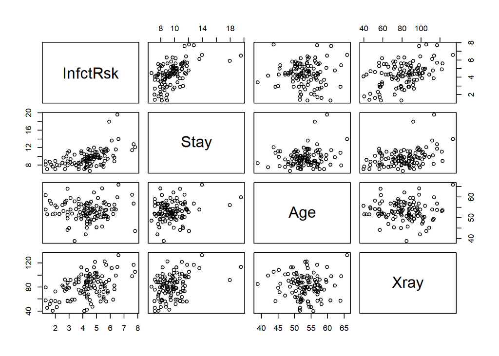

```r
hospital<-read.table("C:/Users/r english/Desktop/r/hospital.txt", header = T)
#1
hos<-hospital[,c("InfctRsk","Stay","Age","Xray")]
plot(hos)
```

```r
cor(hos)
```

```
##             InfctRsk      Stay          Age       Xray
## InfctRsk 1.000000000 0.5334438  0.001093166  0.4533916
## Stay     0.533443831 1.0000000  0.188913972  0.3824819
## Age      0.001093166 0.1889140  1.000000000 -0.0188549
## Xray     0.453391557 0.3824819 -0.018854897  1.0000000
```

```r
cor.test(hospital$Stay,hospital$InfctRsk)
```

```
##
##  Pearson's product-moment correlation
##
## data:  hospital$Stay and hospital$InfctRsk
## t = 6.6445, df = 111, p-value = 1.177e-09
## alternative hypothesis: true correlation is not equal to 0
## 95 percent confidence interval:
##  0.3868338 0.6537511
## sample estimates:
##       cor
## 0.5334438
```

```r
cor.test(hospital$Age,hospital$InfctRsk)
```

```
##
##  Pearson's product-moment correlation
##
## data:  hospital$Age and hospital$InfctRsk
## t = 0.011517, df = 111, p-value = 0.9908
## alternative hypothesis: true correlation is not equal to 0
## 95 percent confidence interval:
##  -0.1836737  0.1857855
## sample estimates:
##         cor
## 0.001093166
```

```r
cor.test(hospital$Xray,hospital$InfctRsk)
```

```
##
##  Pearson's product-moment correlation
##
## data:  hospital$Xray and hospital$InfctRsk
## t = 5.3593, df = 111, p-value = 4.585e-07
## alternative hypothesis: true correlation is not equal to 0
## 95 percent confidence interval:
##  0.2932204 0.5888060
## sample estimates:
##       cor
## 0.4533916
```

```r
#2
lm(hospital$InfctRsk~hospital$Stay+hospital$Age+hospital$Xray)
```

```
##
## Call:
## lm(formula = hospital$InfctRsk ~ hospital$Stay + hospital$Age +
##     hospital$Xray)
##
## Coefficients:
##   (Intercept)  hospital$Stay   hospital$Age  hospital$Xray
##       1.00116        0.30818       -0.02301        0.01966
```

```r
hospital.res<-lm(hospital$InfctRsk~hospital$Stay+hospital$Age+hospital$Xray)
summary(hospital.res)
```

```
##
## Call:
## lm(formula = hospital$InfctRsk ~ hospital$Stay + hospital$Age +
##     hospital$Xray)
##
## Residuals:
##      Min       1Q   Median       3Q      Max
## -2.77320 -0.73779 -0.03345  0.73308  2.56331
##
## Coefficients:
##                Estimate Std. Error t value Pr(>|t|)
## (Intercept)    1.001162   1.314724   0.761 0.448003
## hospital$Stay  0.308181   0.059396   5.189 9.88e-07 ***
## hospital$Age  -0.023005   0.023516  -0.978 0.330098
## hospital$Xray  0.019661   0.005759   3.414 0.000899 ***
## ---
## Signif. codes:  0 '***' 0.001 '**' 0.01 '*' 0.05 '.' 0.1 ' ' 1
##
## Residual standard error: 1.085 on 109 degrees of freedom
## Multiple R-squared:  0.363,  Adjusted R-squared:  0.3455
## F-statistic:  20.7 on 3 and 109 DF,  p-value: 1.087e-10
```

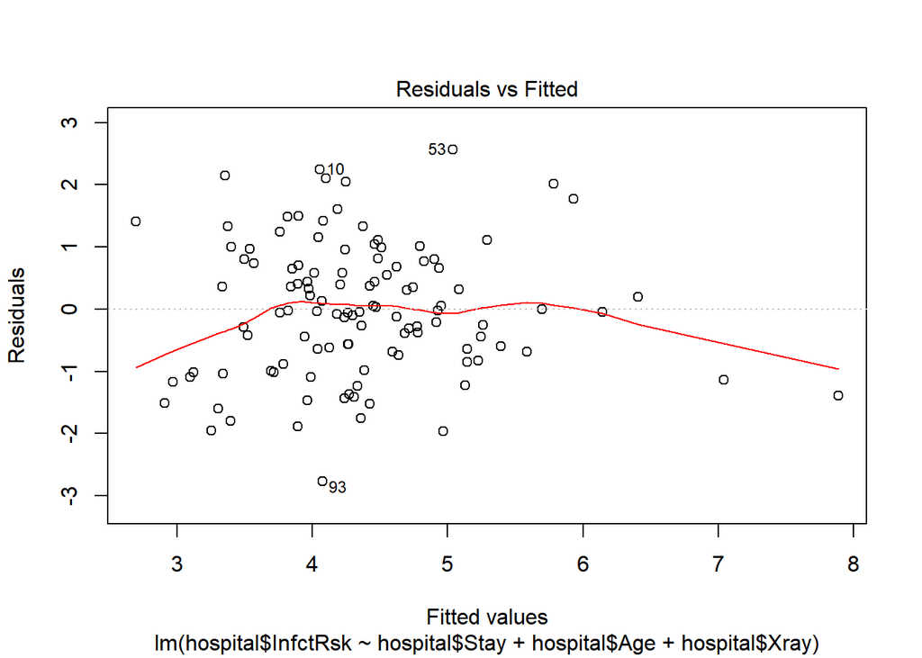

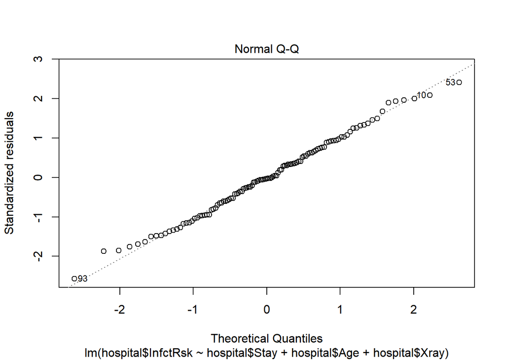

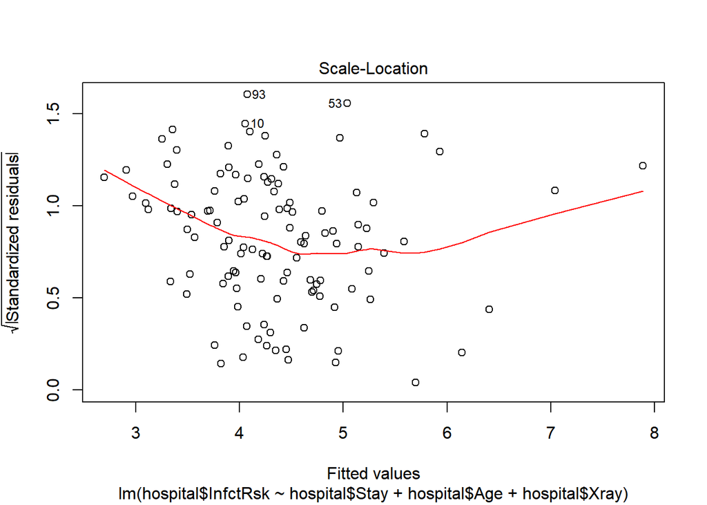

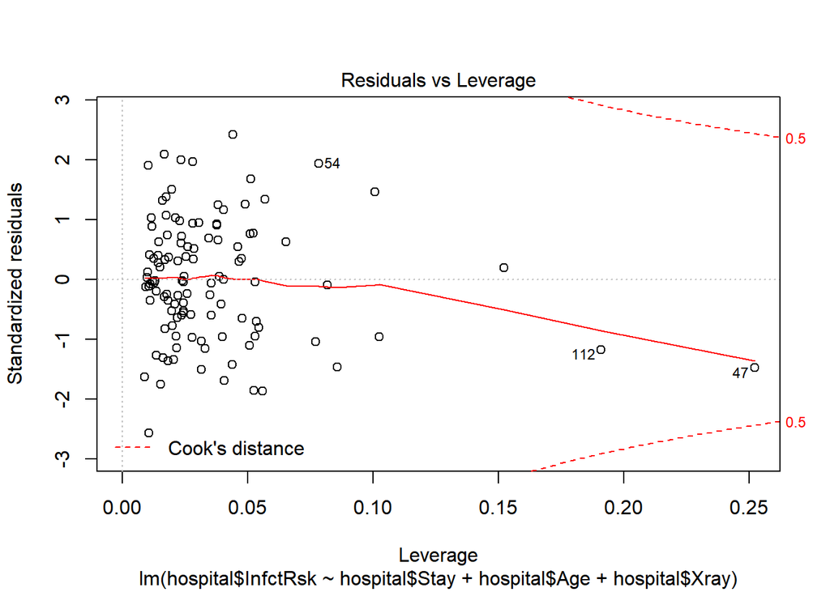

```r
#3
plot(hospital.res)
```

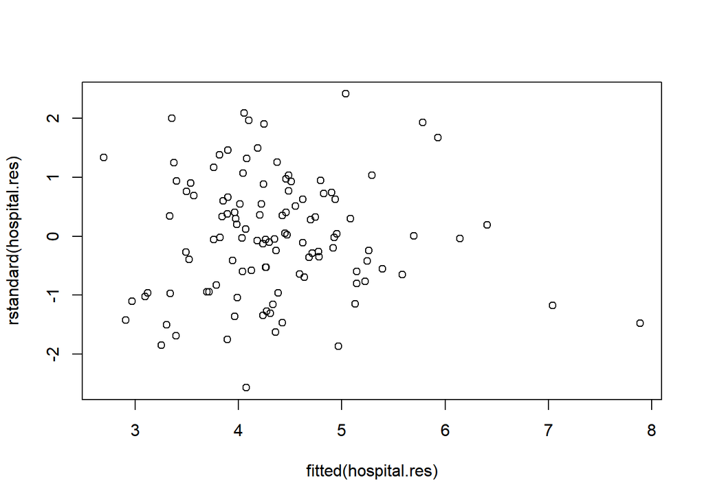

```r
plot(fitted(hospital.res),rstandard(hospital.res))
```

예제 4. 다음의 데이터에 대해 8장 강의노트를 참고하여 행렬 또는 연산 함수들을 이용하여 직접 계산한 과정과 결 과를 나타내시오.

```r
#1
x<-c(4,8,9,10,12,14,6,10,7,11)
y<-c(9,20,22,15,17,30,18,25,11,19)
xbar<-mean(x)
ybar<-mean(y)
r<-sum((x-xbar)*(y-ybar))/sqrt(sum((x-xbar)^2)*sum((y-ybar)^2))
print(r)
```

```
## [1] 0.7180981
```

```r
#2
beta<-sum((x-xbar)*(y-ybar))/sum((x-xbar)^2)
alpha<-ybar-beta*xbar
print(beta)
```

```
## [1] 1.513308
```

```r
print(alpha)
```

```
## [1] 4.828897
```

```r
#3
yhat<-alpha+beta*x
sst<-sum((y-ybar)^2)
sse<-sum((y-yhat)^2)
Rsquare<-(sst-sse)/sst
print(Rsquare)
```

```
## [1] 0.5156649
```

예제 5. sample1.txt 데이터는 임의로 생성한 자료로, 설명변수 1개()와 반응변수()로 이루어진 데이터이다. 이 데이터에 대해 설명변수 를 이용하여 단순 선형 회귀모형을 적용한 후, 잔차도를 이용하여 모형에 대한 4가지 가정 (a) 선형성 (b) 정규성 ⒞ 등분산성 (d) 독립성에 대해 검토하시오.

```r
sample1<-read.table("C:/Users/r english/Desktop/r/sample1.txt", header = T)
lm(sample1$Y~sample1$X)
```

```
##
## Call:
## lm(formula = sample1$Y ~ sample1$X)
##
## Coefficients:
## (Intercept)    sample1$X
##       -2.91        31.60
```

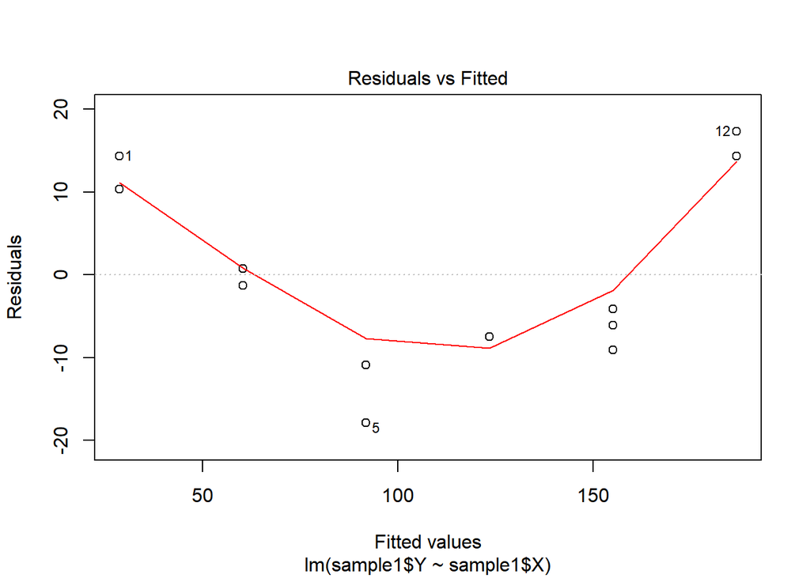

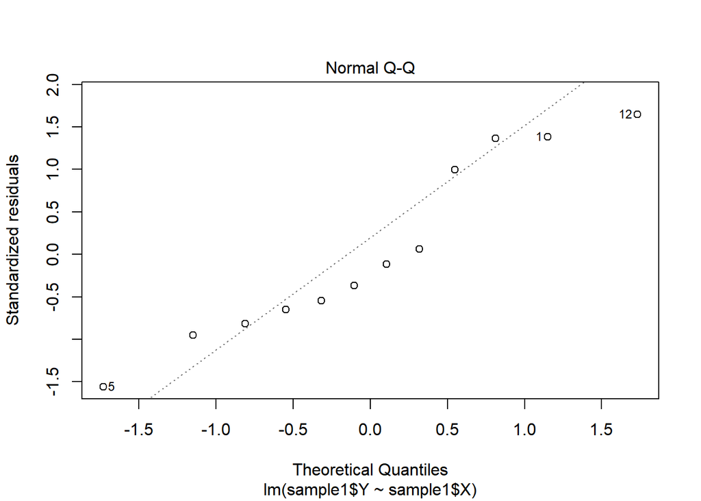

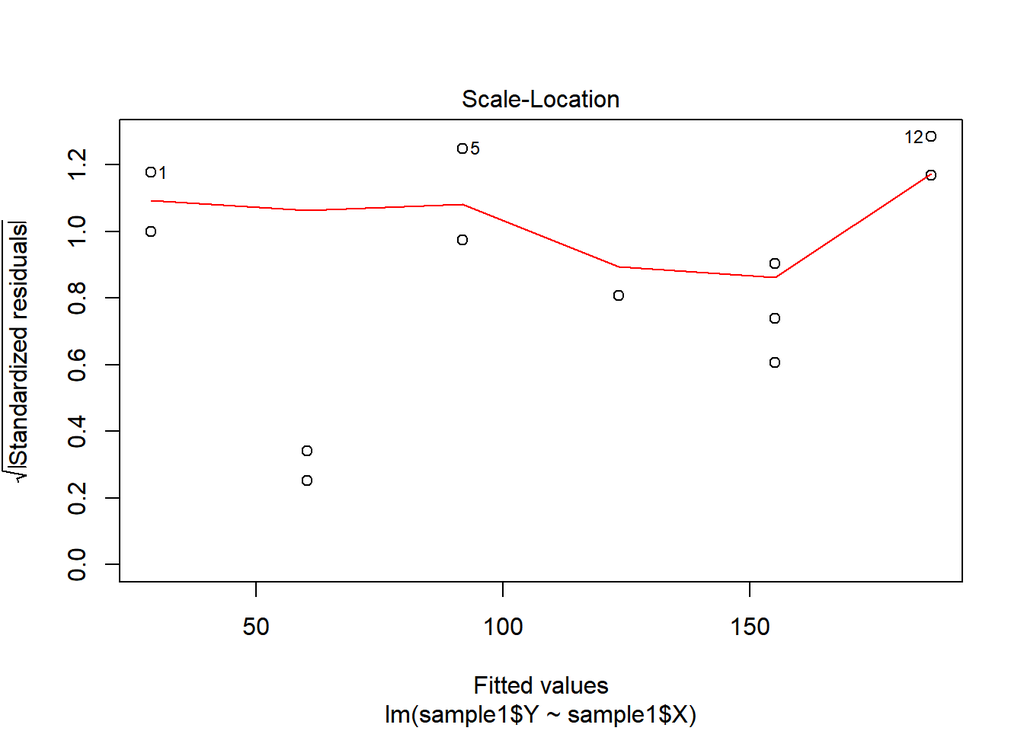

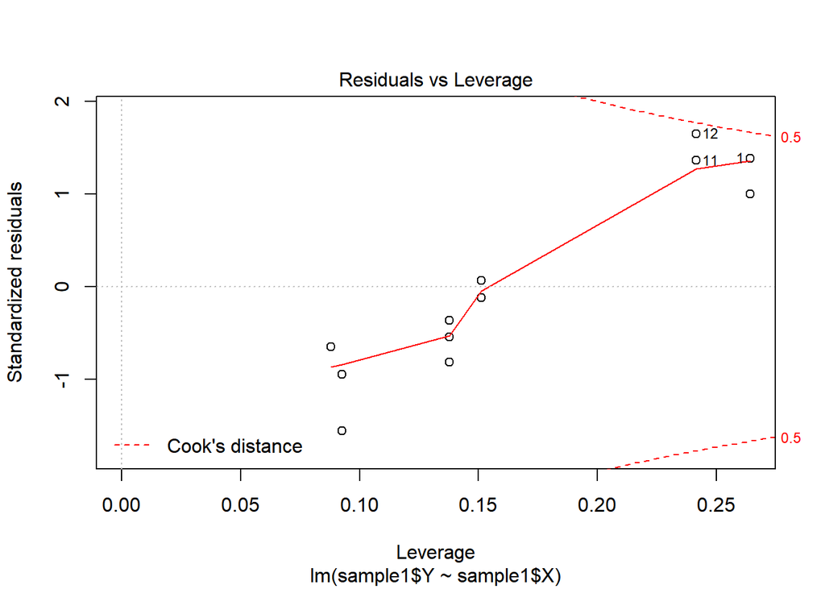

```r
sample1.res<-lm(sample1$Y~sample1$X)
plot(sample1.res)
```

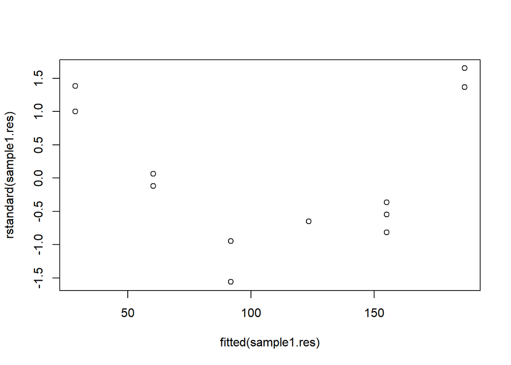

```r
plot(fitted(sample1.res),rstandard(sample1.res))
```

예제6 예제 5에 대한 문제를 해결하기 위해서 반응변수에 log()함수를 적용하여 함수 변환을 시도해보아라. 함수 변환 후 만들어진 새로운 반응변수에 대하여 설명변수 를 이용하여 단순 선형 회귀모형을 적합 시킨 후, 결과를 확 인해보기 위해서 다음의 과정을 수행해보자. (1) 반응변수와 설명변수 간에는 유의한 상관관계가 존재하는가? 산점도와 상관분석을 통해 이를 확인해보자. (2) 단순선형회귀모형을 적용한 후 추정된 회귀식을 구하고, 유의수준 5%에서 모형의 유의성 여부를 검정해보자. 또 한, 결정계수  값을 얼마인가? (3) 단순 선형 회귀모형의 적용은 타당한지 잔차도를 이용하여 확인해보자

```r
log.Y<-log(sample1$Y)
#1
cor(sample1$X,log.Y)
```

```
## [1] 0.9973035
```

```r
cor.test(sample1$X,log.Y)
```

```
##
##  Pearson's product-moment correlation
##
## data:  sample1$X and log.Y
## t = 42.974, df = 10, p-value = 1.118e-12
## alternative hypothesis: true correlation is not equal to 0
## 95 percent confidence interval:
##  0.9900759 0.9992693
## sample estimates:
##       cor
## 0.9973035
```

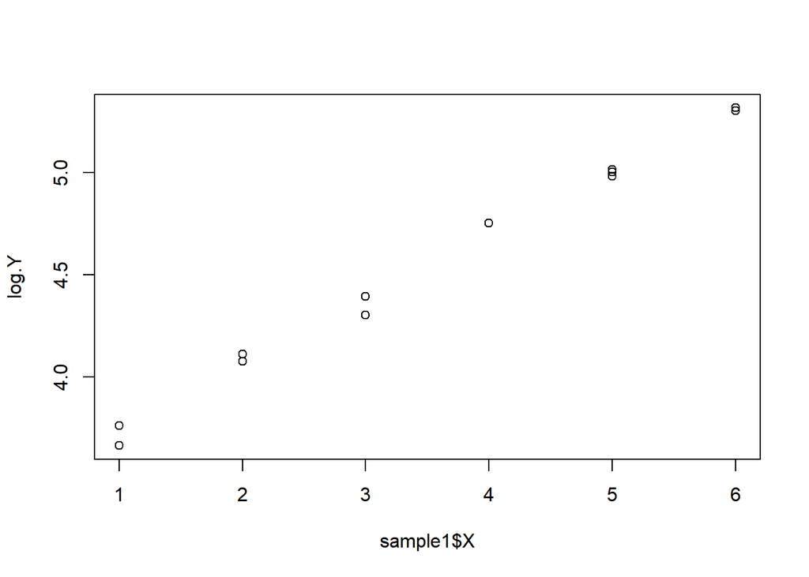

```r
plot(sample1$X,log.Y)
```

```r
#2
lm(log.Y~sample1$X)
```

```
##
## Call:
## lm(formula = log.Y ~ sample1$X)
##
## Coefficients:
## (Intercept)    sample1$X
##      3.4233       0.3166
```

```r
sample11.res<-lm(log.Y~sample1$X)
summary(sample11.res)
```

```
##
## Call:
## lm(formula = log.Y ~ sample1$X)
##
## Residuals:
##       Min        1Q    Median        3Q       Max
## -0.076296 -0.020119  0.004531  0.021377  0.064064
##
## Coefficients:
##             Estimate Std. Error t value Pr(>|t|)
## (Intercept) 3.423302   0.029388  116.49  < 2e-16 ***
## sample1$X   0.316556   0.007366   42.97 1.12e-12 ***
## ---
## Signif. codes:  0 '***' 0.001 '**' 0.01 '*' 0.05 '.' 0.1 ' ' 1
##
## Residual standard error: 0.04476 on 10 degrees of freedom
## Multiple R-squared:  0.9946, Adjusted R-squared:  0.9941
## F-statistic:  1847 on 1 and 10 DF,  p-value: 1.118e-12
```